# Popularity of Music Explained

Member 1: Katya Kiryutin, Contribution: 95% (Did not contribute to H)

Member 2: Areeb Malik, Contribution: 90% (Did not contribute to A,E)

Member 3: Arjun Sharma, Contribution: 95% (did not contribute to H)

We, all team members, agree together that the above information is true, and we are confident about our contributions to this submitted project/final tutorial. Areeb Malik, Katya Kiryutin, Arjun Sharma.

Katya Kiryutin --> she delivered with the Chi-Squared test portion of the data analysis portion. She made the graphs for the ML analysis and she assisted with testing for ML algorithm.

Areeb Malik --> Wrote paragraphs describing the flow of the tutorial. Assissted with T-test analysis and also assisted with graphs.

Arjun Sharma --> Wrote majority of ML algorithm and and did the Pearson test. Assited with graphs and training ML data

## Spring 2024 Data Science Project By: Areeb Malik, Arjun Sharma, Katya Kiryutin

# **1: Introduction**

Music is a fascinating thing. It comes in many different forms, and many people have different tastes when it comes to music. Every day, songs gain attention across various platforms—whether it's trending on TikTok, dominating radio waves, or sparking conversations on social media. The abundance of music poses an interesting question. What drives a song's popularity? Given the vast diversity of genres and styles, how do certain tracks resonate so profoundly with audiences worldwide?

Our project seeks to reveal the mysteries behind the trends in popular music. We aim to identify the specific elements that contribute to a song's success. Is it the BPM, the danceability, the genre, or none of them? By analyzing these factors, we hope to discover patterns or perhaps even a 'formula' that could predict a song's popularity.

# **2: Managing our Data**

The data we used is from Kaggle: https://www.kaggle.com/datasets/maharshipandya/-spotify-tracks-dataset We downloaded it as a CSV to utilize in our analysis.

After importing our libraries, let's load in our data set from our google drive. This makes it easier so that we don't have to always import our dataset whenever we open Google Colab.

```python
import pandas as pd
import matplotlib.pyplot as plt
import scipy.stats as stats
```

```python
from google.colab import drive
drive.mount('/content/drive', force_remount=True)
```

# **2.1: Cleaning our Data**

We see that we had saved our selves from looking through an extra 24,259 track_ids because we had dropped the duplicates values. If we had kept this in, we could have had skewed values pointing to one attribute because of these duplicates.

```python
df_1 = pd.read_csv('/content/drive/MyDrive/CMSC320 Final Project/dataset.csv')
df = df_1.drop_duplicates(subset=['track_id'])
df = df.rename(columns={"Unnamed: 0": "ID"})
df = df.drop(columns=['ID'])
display(len(df_1))
display(len(df))
display("Number of Duplicates: " + str(len(df_1) - len(df)))
display(df)
```

```
114000
```

```
89741
```

```
'Number of Duplicates: 24259'
```

|  | track_id | artists | album_name | track_name | popularity | duration_ms | explicit | danceability | energy | key | loudness | mode | speechiness | acousticness | instrumentalness | liveness | valence | tempo | time_signature | track_genre |
| --- | --- | --- | --- | --- | --- | --- | --- | --- | --- | --- | --- | --- | --- | --- | --- | --- | --- | --- | --- | --- |
| 0 | 5SuOikwiRyPMVoIQDJUgSV | Gen Hoshino | Comedy | Comedy | 73 | 230666 | False | 0.676 | 0.4610 | 1 | -6.746 | 0 | 0.1430 | 0.0322 | 0.000001 | 0.3580 | 0.7150 | 87.917 | 4 | acoustic |
| 1 | 4qPNDBW1i3p13qLCt0Ki3A | Ben Woodward | Ghost (Acoustic) | Ghost - Acoustic | 55 | 149610 | False | 0.420 | 0.1660 | 1 | -17.235 | 1 | 0.0763 | 0.9240 | 0.000006 | 0.1010 | 0.2670 | 77.489 | 4 | acoustic |
| 2 | 1iJBSr7s7jYXzM8EGcbK5b | Ingrid Michaelson;ZAYN | To Begin Again | To Begin Again | 57 | 210826 | False | 0.438 | 0.3590 | 0 | -9.734 | 1 | 0.0557 | 0.2100 | 0.000000 | 0.1170 | 0.1200 | 76.332 | 4 | acoustic |
| 3 | 6lfxq3CG4xtTiEg7opyCyx | Kina Grannis | Crazy Rich Asians (Original Motion Picture Sou... | Can't Help Falling In Love | 71 | 201933 | False | 0.266 | 0.0596 | 0 | -18.515 | 1 | 0.0363 | 0.9050 | 0.000071 | 0.1320 | 0.1430 | 181.740 | 3 | acoustic |
| 4 | 5vjLSffimiIP26QG5WcN2K | Chord Overstreet | Hold On | Hold On | 82 | 198853 | False | 0.618 | 0.4430 | 2 | -9.681 | 1 | 0.0526 | 0.4690 | 0.000000 | 0.0829 | 0.1670 | 119.949 | 4 | acoustic |
| ... | ... | ... | ... | ... | ... | ... | ... | ... | ... | ... | ... | ... | ... | ... | ... | ... | ... | ... | ... | ... |
| 113995 | 2C3TZjDRiAzdyViavDJ217 | Rainy Lullaby | #mindfulness - Soft Rain for Mindful Meditatio... | Sleep My Little Boy | 21 | 384999 | False | 0.172 | 0.2350 | 5 | -16.393 | 1 | 0.0422 | 0.6400 | 0.928000 | 0.0863 | 0.0339 | 125.995 | 5 | world-music |
| 113996 | 1hIz5L4IB9hN3WRYPOCGPw | Rainy Lullaby | #mindfulness - Soft Rain for Mindful Meditatio... | Water Into Light | 22 | 385000 | False | 0.174 | 0.1170 | 0 | -18.318 | 0 | 0.0401 | 0.9940 | 0.976000 | 0.1050 | 0.0350 | 85.239 | 4 | world-music |
| 113997 | 6x8ZfSoqDjuNa5SVP5QjvX | Cesária Evora | Best Of | Miss Perfumado | 22 | 271466 | False | 0.629 | 0.3290 | 0 | -10.895 | 0 | 0.0420 | 0.8670 | 0.000000 | 0.0839 | 0.7430 | 132.378 | 4 | world-music |
| 113998 | 2e6sXL2bYv4bSz6VTdnfLs | Michael W. Smith | Change Your World | Friends | 41 | 283893 | False | 0.587 | 0.5060 | 7 | -10.889 | 1 | 0.0297 | 0.3810 | 0.000000 | 0.2700 | 0.4130 | 135.960 | 4 | world-music |
| 113999 | 2hETkH7cOfqmz3LqZDHZf5 | Cesária Evora | Miss Perfumado | Barbincor | 22 | 241826 | False | 0.526 | 0.4870 | 1 | -10.204 | 0 | 0.0725 | 0.6810 | 0.000000 | 0.0893 | 0.7080 | 79.198 | 4 | world-music |

89741 rows × 20 columns

Now before we delve deep into analyzing our data let's just take a look at some of the most popular genres! First we want to be able to see their index so we will apll the reset_index() function

# **3: Exploratory analysis: Finding popular and least popular Genres**

```python
df_mean = df.groupby('track_genre')['popularity'].mean().sort_values(ascending=False)
df2 = df_mean.reset_index()
df2.set_index('track_genre', inplace=True)
display(df2.head(30))
```

| track_genre | popularity |
| --- | --- |
| k-pop | 59.358779 |
| pop-film | 59.096933 |
| metal | 56.422414 |
| chill | 53.738683 |
| latino | 51.788945 |
| sad | 51.109929 |
| grunge | 50.587007 |
| indian | 49.765348 |
| anime | 48.776884 |
| emo | 48.500000 |
| reggaeton | 48.270270 |
| sertanejo | 47.860775 |
| piano | 46.608312 |
| progressive-house | 46.537748 |
| hard-rock | 45.744711 |
| pagode | 45.585799 |
| deep-house | 45.573045 |
| mandopop | 45.071019 |
| british | 44.768889 |
| metalcore | 44.708914 |
| brazil | 44.645678 |
| electronic | 44.234940 |
| ambient | 44.208208 |
| singer-songwriter | 43.592030 |
| acoustic | 42.483000 |
| hip-hop | 42.429929 |
| pop | 41.944712 |
| punk | 41.884956 |
| forro | 41.831663 |
| world-music | 41.536295 |

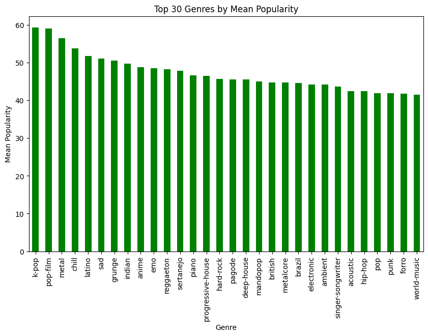

```python
plt.figure(figsize=(10, 6))
df2.head(30)['popularity'].plot(kind='bar', color='green')
plt.title('Top 30 Genres by Mean Popularity')
plt.xlabel('Genre')
plt.ylabel('Mean Popularity')
plt.show()
```

Let's see what the 10 least popular genres are!

```python
display(df2.tail(10))
```

| track_genre | popularity |
| --- | --- |
| idm | 15.522222 |
| kids | 14.770791 |
| grindcore | 14.521827 |
| classical | 13.362168 |
| chicago-house | 12.333667 |
| detroit-techno | 11.130753 |
| latin | 9.855072 |
| jazz | 9.790076 |
| romance | 3.549779 |
| iranian | 2.224696 |

Very interesting to see that kids is ranked as the 9th least listened to genre. 5 of 10 most viewed youtube vidoes are kids songs with Baby Shark amassing over 14 Billion views! 6 billion more than the next video which is Despacito. https://en.wikipedia.org/wiki/List_of_most-viewed_YouTube_videos This could be because most kids do not use spotify and instead they are always on their parents phone watching Youtube Kids.

Now let's see the graph for the bottom 10!

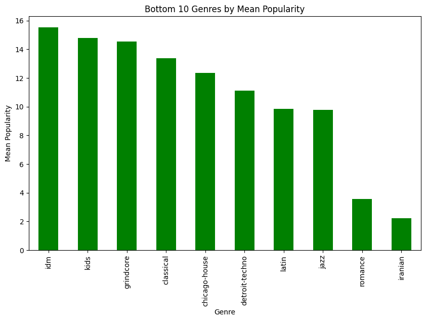

```python
plt.figure(figsize=(10, 6))
df2.tail(10)['popularity'].plot(kind='bar', color='green')
plt.title('Bottom 10 Genres by Mean Popularity')
plt.xlabel('Genre')
plt.ylabel('Mean Popularity')
plt.show()
```

Poor Iranian music :(

# **3.1: Testing our Data**

Now we want to see different testing methods on out data via using different elements that define a song such as their genre, how danceable each song is, tempo etc...

For the three hypothesis tests below, we will use a significance level of $\alpha$ = 0.05

**Pearson Test**

H0: danceability does not have an effect on popularity

HA: danceability does have an effect on popularity

Because we want to find correlation between what makes a song popular, we will look at the danceibility of the song. We will take the correlation value and the p-value to determine this.

```python
pop_data = df[df['track_genre'] == 'pop'][['danceability', 'popularity']].dropna()
hiphop_data = df[df['track_genre'] == 'hip-hop'][['danceability', 'popularity']].dropna()
print(pop_data)

pop_corr, pop_p = stats.pearsonr(pop_data['danceability'], pop_data['popularity'])

print(f'pop correlation: {pop_corr}, pop p value: {pop_p}')
```

```
       danceability  popularity
81000         0.514          91
81004         0.679          90
81006         0.724          74
81009         0.772          76
81012         0.410          90
...             ...         ...
81989         0.599          64
81990         0.668          64
81992         0.766          63
81993         0.741          64
81994         0.876          64

[416 rows x 2 columns]
pop correlation: 0.10307501506514821, pop p value: 0.03558825695481653
```

For pop music, the p-value of 0.0356 is lower than the significance level of 0.05 so we reject the null hypothesis and claim that danceability does affect popularity. This makes sense as one would expect pop to be catchy and easy to jam to. We also see that there is a correlation coefficent of 0.103, which shows a positive correlation but it is not a big coefficent so it is not a strong correlation, but there is a correlation.

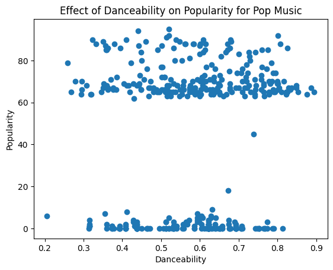

```python
plt.scatter(pop_data['danceability'], pop_data['popularity'])
plt.title('Effect of Danceability on Popularity for Pop Music')
plt.xlabel('Danceability')
plt.ylabel('Popularity')
```

**T-Test**

We will determine if liveliness affects popularity but utilize a T Test to look at the difference between the means of the two groups.

```
TtestResult(statistic=array([-3.9950668 , -0.23588592]), pvalue=array([6.89804197e-05, 8.13586897e-01]), df=array([1099.34611991,  735.13326543]))
```

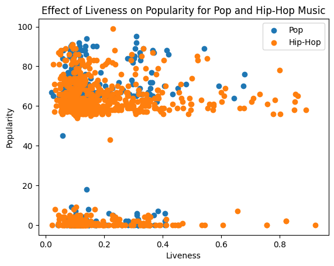

```python
pop_data_clean = pop_data.dropna()
hiphop_data_clean = hiphop_data.dropna()

pop_data = df[df['track_genre'] == 'pop'][['liveness', 'popularity']].dropna()
hiphop_data = df[df['track_genre'] == 'hip-hop'][['liveness', 'popularity']].dropna()

print(stats.ttest_ind(pop_data, hiphop_data, equal_var=False))

plt.scatter(pop_data['liveness'], pop_data['popularity'], label="Pop")
plt.scatter(hiphop_data['liveness'], hiphop_data['popularity'], label="Hip-Hop")
plt.title('Effect of Liveness on Popularity for Pop and Hip-Hop Music')
plt.legend()
plt.xlabel('Liveness')
plt.ylabel('Popularity')
```

H0: The genre (category) of the song does not affect tempo

HA: The genre (category) of the song does affect tempo

```
F_onewayResult(statistic=5.031362739035586, pvalue=0.006659749277153722)
```

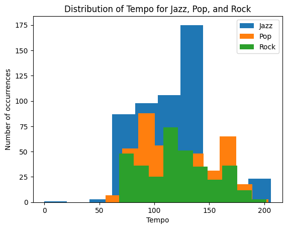

```python
pop = df[df['track_genre'] == 'pop']['tempo'].dropna()
rock = df[df['track_genre'] == 'rock']['tempo'].dropna()
jazz = df[df['track_genre'] == 'jazz']['tempo'].dropna()
allthree = df[(df['track_genre'] == 'pop') & (df['track_genre'] == 'rock') & (df['track_genre'] == 'jazz')]
allthree = df[df['track_genre'].isin(['pop', 'rock', 'jazz'])]

print(stats.f_oneway(pop, rock, jazz))

# plt.scatter(allthree['track_genre'], allthree['tempo'])
# plt.xlabel('Genres')
# plt.ylabel('Tempo')
plt.hist(df[df['track_genre'] == 'jazz']['tempo'], label="Jazz")
plt.hist(df[df['track_genre'] == 'pop']['tempo'], label="Pop")
plt.hist(df[df['track_genre'] == 'rock']['tempo'], label="Rock")
plt.legend()
plt.title('Distribution of Tempo for Jazz, Pop, and Rock')
plt.xlabel('Tempo')
plt.ylabel('Number of occurrences')
```

The p-value is lower than the significance level of 0.05 so genre does affect tempo. We can see in the graph that jazz has many more songs at its peak tempo bar compared to pop and rock having a more even spread with most of their songs being at the lower end of their tempo ranges.

# **4. Primary analysis and visualization**

A linear regression was used to determine if there was any relationships between the columns that could be explored.

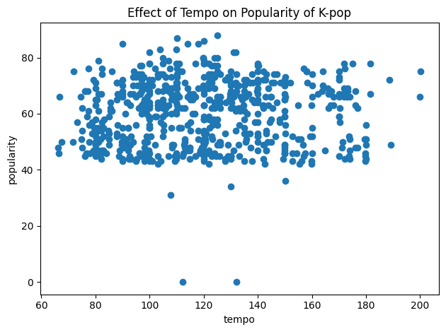

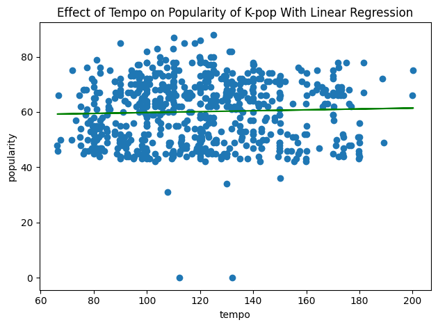

```
Cross-validation accuracy (mean): -0.0011768987242749551
Cross-validation accuracy (std): 0.003464192059949629

MSE Train: 133.5647178732994
MSE Test: 192.24413045740053
R2 Train: 0.0014804277957974898
R2 Test: 0.008167105607016056
```

```python
from sklearn.model_selection import train_test_split, cross_val_score, StratifiedKFold
from sklearn.preprocessing import StandardScaler
from sklearn.linear_model import LinearRegression
from sklearn.metrics import mean_squared_error, r2_score


df_pt = df[['track_genre', 'popularity', 'tempo']]
df_filtered = df_pt[df_pt['track_genre'] == 'k-pop']
df_pt_filtered = df_filtered[['popularity', 'tempo']]
# df_encoded = pd.get_dummies(df_p, columns=['track_genre'])
# df_encoded

X = df_pt_filtered.drop('popularity', axis=1)
y = df_pt_filtered['popularity']

X_train, X_test, y_train, y_test = train_test_split(X, y, test_size=0.3, random_state=42)

plt.scatter(X_train, y_train)
plt.title('Effect of Tempo on Popularity of K-pop')
plt.xlabel('tempo')
plt.ylabel('popularity')
plt.tight_layout()
plt.show()

y_train_pred = LinearRegression().fit(X_train, y_train).predict(X_train)
y_test_pred = LinearRegression().fit(X_test, y_test).predict(X_test)

plt.scatter(X_train, y_train)
plt.plot(X_train, y_train_pred, color='green', label='Linear Regression')
plt.title('Effect of Tempo on Popularity of K-pop With Linear Regression')
plt.xlabel('tempo')
plt.ylabel('popularity')
plt.tight_layout()
plt.show()

scaler = StandardScaler()
X_train_scaled = scaler.fit_transform(X_train)
X_test_scaled = scaler.transform(X_test)

skf = StratifiedKFold(n_splits=5, shuffle=True, random_state=42)
cv_scores = cross_val_score(LinearRegression(), X_train_scaled, y_train, cv=skf)

print(f"Cross-validation accuracy (mean): {cv_scores.mean()}")
print(f"Cross-validation accuracy (std): {cv_scores.std()}\n")

mse_train = mean_squared_error(y_train, y_train_pred)
mse_test = mean_squared_error(y_test, y_test_pred)
r2_train = r2_score(y_train, y_train_pred)
r2_test = r2_score(y_test, y_test_pred)

print(f"MSE Train: {mse_train}")
print(f"MSE Test: {mse_test}")
print(f"R2 Train: {r2_train}")
print(f"R2 Test: {r2_test}")


# using a linear regression, we can see that there is not much of a correlation
# between popularity and tempo, as shown with k-pop as an example
```

[figure not shown]

[figure not shown]

```
Cross-validation accuracy (mean): -0.0011768987242749551
Cross-validation accuracy (std): 0.003464192059949629

MSE Train: 133.5647178732994
MSE Test: 192.24413045740053
R2 Train: 0.0014804277957974898
R2 Test: 0.008167105607016056
```

```python
df_pd = df[['track_genre', 'popularity', 'danceability']]
df_filtered = df_pd[df_pd['track_genre'] == 'k-pop']
df_pd_filtered = df_filtered[['popularity', 'danceability']]

X = df_pt_filtered.drop('popularity', axis=1)
y = df_pt_filtered['popularity']

X_train, X_test, y_train, y_test = train_test_split(X, y, test_size=0.3, random_state=42)

plt.scatter(X_train, y_train)
plt.title('Effect of Danceability on Popularity for K-pop')
plt.xlabel('danceability')
plt.ylabel('popularity')
plt.tight_layout()
plt.show()

y_train_pred = LinearRegression().fit(X_train, y_train).predict(X_train)
y_test_pred = LinearRegression().fit(X_test, y_test).predict(X_test)

plt.scatter(X_train, y_train)
plt.plot(X_train, y_train_pred, color='green', label='Linear Regression')
plt.title('Effect of Danceability on Popularity for K-pop With Linear Regression')
plt.xlabel('danceability')
plt.ylabel('popularity')
plt.tight_layout()
plt.show()

scaler = StandardScaler()
X_train_scaled = scaler.fit_transform(X_train)
X_test_scaled = scaler.transform(X_test)

skf = StratifiedKFold(n_splits=5, shuffle=True, random_state=42)
cv_scores = cross_val_score(LinearRegression(), X_train_scaled, y_train, cv=skf)

print(f"Cross-validation accuracy (mean): {cv_scores.mean()}")
print(f"Cross-validation accuracy (std): {cv_scores.std()}\n")

mse_train = mean_squared_error(y_train, y_train_pred)
mse_test = mean_squared_error(y_test, y_test_pred)
r2_train = r2_score(y_train, y_train_pred)
r2_test = r2_score(y_test, y_test_pred)

print(f"MSE Train: {mse_train}")
print(f"MSE Test: {mse_test}")
print(f"R2 Train: {r2_train}")
print(f"R2 Test: {r2_test}")
```

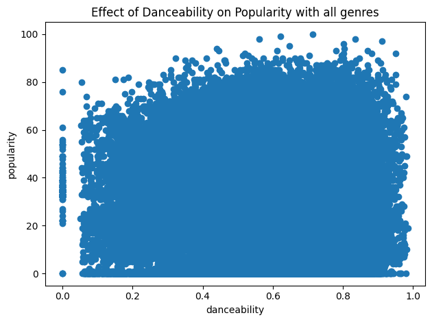

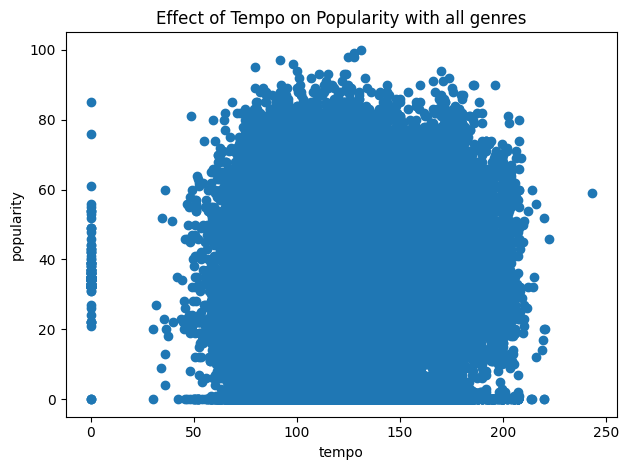

```python
df_pd = df[['popularity', 'danceability']]
df_pt = df[['popularity', 'tempo']]

X1 = df_pd.drop('popularity', axis=1)
y1 = df_pd['popularity']

X2 = df_pt.drop('popularity', axis=1)
y2 = df_pt['popularity']

X1_train, X1_test, y1_train, y1_test = train_test_split(X1, y1, test_size=0.3, random_state=42)
X2_train, X2_test, y2_train, y2_test = train_test_split(X2, y2, test_size=0.3, random_state=42)

plt.scatter(X1_train, y1_train)
plt.title('Effect of Danceability on Popularity with all genres')
plt.xlabel('danceability')
plt.ylabel('popularity')
plt.tight_layout()
plt.show()

plt.scatter(X2_train, y2_train)
plt.title('Effect of Tempo on Popularity with all genres')
plt.xlabel('tempo')
plt.ylabel('popularity')
plt.tight_layout()
plt.show()
```

# **5. Insights and Conclusions**